# Final Project

**Name**: Gathu Macharia

```r
#install.packages("vip")
```

```r
# Suppress dplyr summarise grouping warning messages
options(dplyr.summarise.inform = FALSE)

## Add R libraries here
#library(tidyverse)
library(tidymodels)
library(klaR)
library(kknn)
library(discrim)
library(vip)
library(rpart.plot)
library(ranger)
library(readr)


# Load data
loans_df <- read_rds("/home/gathu/Documents/CLASSES/data science/datascience with r/logistic  bank default/default/Bank-Loan-Analysis-Using-R/loan_data.rds")
```

# Data Analysis [30 Points]

## Question 1

**Question**: Are there differences in loan default rates by interest rates?

**Answer**: As the plot shows, there is a difference between the average interest rates for those that do default their loan compared to those who do not. The average interest rate for a defaulted loan is just under 15%, compared to just over 9% for non defaulted loans. With almost a 6% difference between the two, it can be said that the interest rate does play a part in determining whether or not someone defaults their loans.

```r
interest_rates <- loans_df %>%
  group_by(loan_default) %>%
  summarise(n_customers = n(),
            avg_int_rate = round(mean(interest_rate),2))
interest_rates
```

| loan_default | n_customers | avg_int_rate |
| --- | --- | --- |
| yes | 1530 | 14.89 |
| no | 2580 | 9.30 |

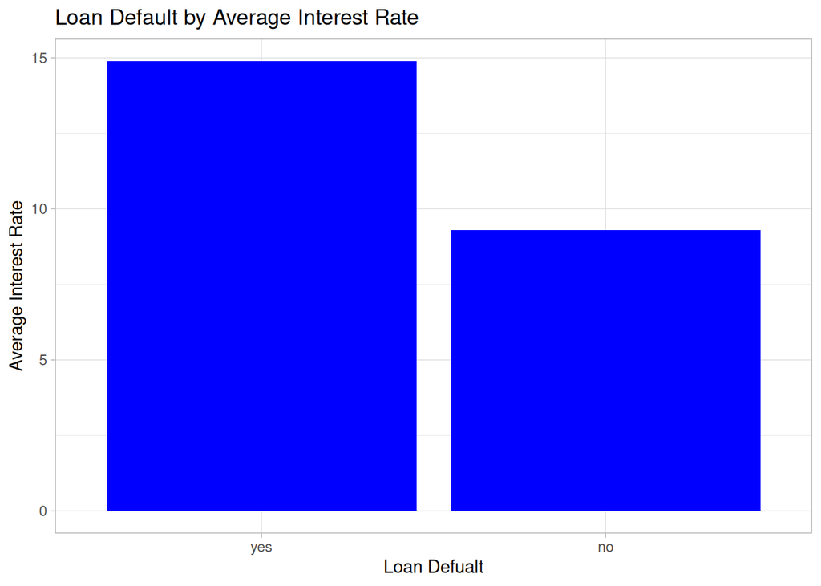

```r
ggplot(data = interest_rates, mapping = aes(x = loan_default, y =avg_int_rate)) +
  geom_bar(stat = 'identity', fill = "blue") +
  labs(title = "Loan Default by Average Interest Rate",
       x = "Loan Defualt",
       y = "Average Interest Rate") +
  theme_light()
```

## Question 2

**Question**: Does the loan purpose have an impact on the interest rate?

**Answer**: Based on the tibble below, it can be seen that credit cards and medical purposes have the highest average interest rates, with 12.36% and 12.85% respectively. All other loan purposes have an average interest rate below 11%. The loan with the highest default rate were the medical loans, followed by credit card loans.

```r
loans_df %>% group_by(loan_purpose) %>%
  summarise(avg_interest = round(mean(interest_rate), 2),
            avg_loan_amount = round(mean(loan_amount), 2),
            default_percent = 100 * round(mean(loan_default == "yes"),4))
```

| loan_purpose | avg_interest | avg_loan_amount | default_percent |
| --- | --- | --- | --- |
| debt_consolidation | 10.62 | 16598.62 | 25.29 |
| credit_card | 12.36 | 16656.23 | 53.47 |
| medical | 12.85 | 16890.98 | 60.47 |
| small_business | 10.70 | 16695.22 | 25.91 |
| home_improvement | 10.86 | 16728.81 | 28.00 |

## Question 3

**Question**: Does the type of home ownership and average income have a relation to the average debt to income?

**Answer**: It can be seen that there is a relationship between home ownership, average annual income, and the average debt to income. People with mortgages have the highest annual income and the highest average debt to income, owning has the second highest average annual income and average debt to income, and renting has the lowest average annual income and average debt to income.

```r
loans_df %>% group_by(homeownership) %>%
  summarise(avg_ann_income = round(mean(annual_income),2),
            avg_debt_to_income = round(mean(debt_to_income),2),
            default_percent = 100 * mean(loan_default == "yes")) %>%
  arrange(desc(avg_debt_to_income))
```

| homeownership | avg_ann_income | avg_debt_to_income | default_percent |
| --- | --- | --- | --- |
| mortgage | 81239.48 | 21.26 | 32.42127 |
| own | 68759.11 | 19.34 | 37.27811 |
| rent | 64747.88 | 18.83 | 42.79712 |

## Question 4

**Question**: Does the term impact the loan default rate?

**Answer**: Yes, the term does impact the default rate. Five year terms have more people defaulting, and have an average default rate of 54.99%, compared to just 26.78% defaulted by three year terms.

```r
loans_df %>% group_by(term) %>%
  summarise(num_default = sum(loan_default == "yes"),
            default_percent = round(100* mean(loan_default == "yes"),2))
```

| term | num_default | default_percent |
| --- | --- | --- |
| three_year | 693 | 26.78 |
| five_year | 837 | 54.99 |

## Question 5

**Question**: Is interest rate dependent on loan amount?

**Answer**: When plotting the loan amounts vs. interest rates, it can be seen that no matter the amount of the loan, the interest rate can range anywhere from the lowest amount to the highest amount possible. Based on the scatter plot, it can be said that there is no relationship between the interest rate and the amount of the loan. However, there is a higher concentration of 5%-15% interest rates between $0-$15,000 loans.

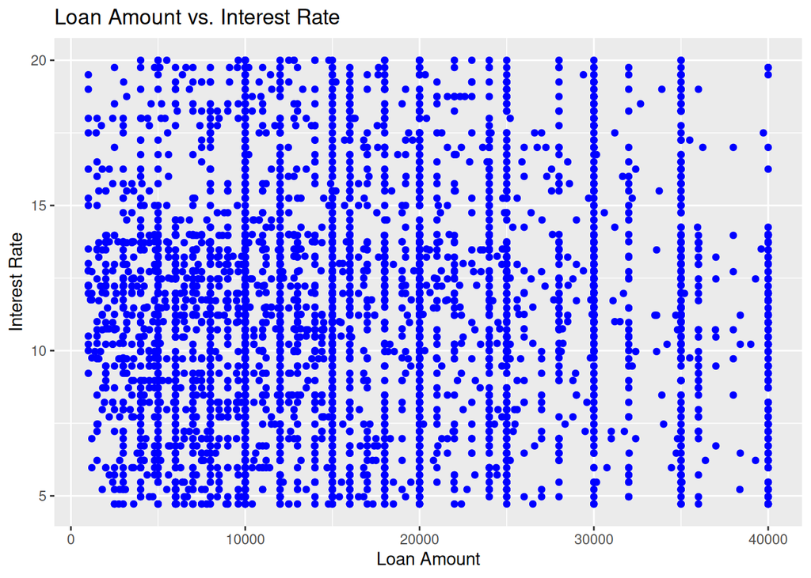

```r
ggplot(data = loans_df, mapping = aes(x = loan_amount, y = interest_rate)) +
  geom_point(color = "blue") +
  labs(title = "Loan Amount vs. Interest Rate",
       x = "Loan Amount",
       y = "Interest Rate")
```

## Question 6

**Question**: Does having a history of bankruptcy have an impact on the interest rate between those who default their loans or not?

**Answer**: From the histogram below, it can be concluded that whether or not someone was bankrupt does not impact their interest rate. However, whether they defaulted their loan also plays an important factor. While almost every interest rate is over 10% for a bankrupt person that defaulted their loan, for a bankrupt person who did not default their interest rate ranges between just under 5% to just under 15%; almost a 10% range. An almost identical histogram can be seen for those who were not bankrupt in regards to their interest rates. The main factor that can be seen in these histograms is that those who have defaulted their loans have a much higher interest rate.

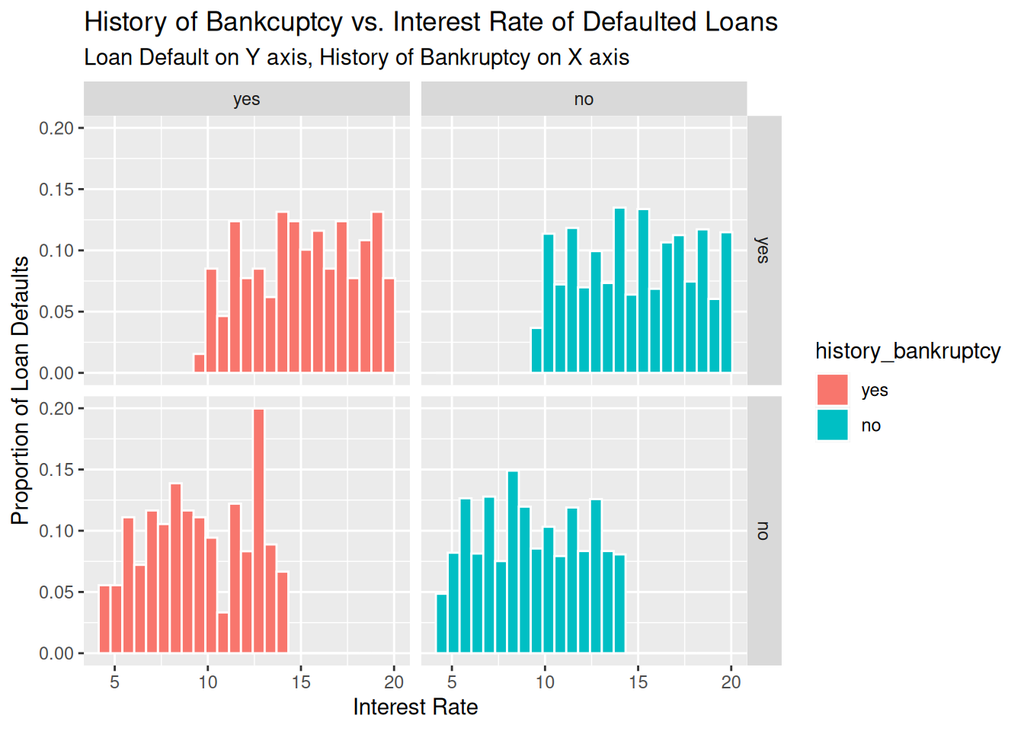

```r
ggplot(loans_df, aes(x = interest_rate, y = ..density.., color = history_bankruptcy, fill = history_bankruptcy)) +
  geom_histogram(color = "white", bins = 25) +
  facet_grid(loan_default~history_bankruptcy) +
  labs(title = "History of Bankcuptcy vs. Interest Rate of Defaulted Loans",
       subtitle = "Loan Default on Y axis, History of Bankruptcy on X axis",
       x = "Interest Rate",
       y = "Proportion of Loan Defaults")
```

# Predictive Modeling [70 Points]

## Model 1: Logistic Regression

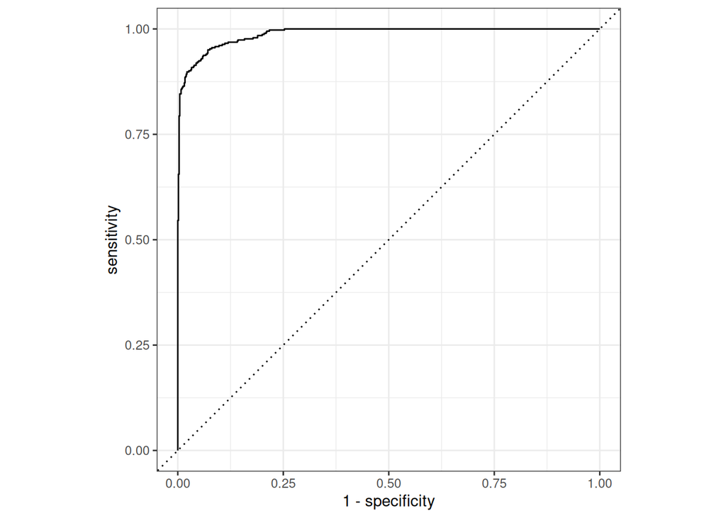

```r
#Create Split, training, and test
set.seed(150)

loans_split <- initial_split(loans_df, prop = 0.75, strata = loan_default)

loans_training <- loans_split %>% training()

loans_test <- loans_split %>% testing()

#Cross validation folds for hyperparameter tuning
set.seed(75)
loans_folds <- vfold_cv(loans_training, v = 5)

#Feature Engineering
loans_recipe <- recipe(loan_default ~ ., data = loans_training) %>%
  step_YeoJohnson(all_numeric(), -all_outcomes()) %>%
  step_normalize(all_numeric(), -all_outcomes()) %>%
  step_dummy(all_nominal(), -all_outcomes())

#Logistic Regression Model Specification
logistic_model <- logistic_reg() %>%
  set_engine('glm') %>%
  set_mode('classification')

#Create Workflow
logistic_wf <- workflow() %>%
  add_model(logistic_model) %>%
  add_recipe(loans_recipe)

#Fit Model
logistic_fit <- logistic_wf %>%
  last_fit(split = loans_split)

#Collect Predictions
logistic_results <- logistic_fit %>%
  collect_predictions()


# Assuming logistic_results is your data frame
roc_curve_data <- roc_curve(logistic_results,
                             truth = loan_default,
                             .pred_yes)

# Plotting the ROC curve
autoplot(roc_curve_data)
```

```r
#ROC Area Under Curve
roc_auc(logistic_results, truth = loan_default, .pred_yes)
```

| .metric | .estimator | .estimate |
| --- | --- | --- |
| roc_auc | binary | 0.9879572 |

```r
#Confusion Matrix
conf_mat(logistic_results, truth = loan_default, .pred_class)
```

```
##           Truth
## Prediction yes  no
##        yes 352  29
##        no   31 616
```

## Model 2: KNN

```r
#KNN Model Specifcation
knn_model <- nearest_neighbor(neighbors = tune()) %>%
  set_engine('kknn') %>%
  set_mode('classification')

#Create Workflow
knn_wf <- workflow() %>%
  add_model(knn_model) %>%
  add_recipe(loans_recipe)

#Create grid of values to test
k_grid <- tibble(neighbors = c(10, 20, 30, 50 , 75, 100, 125, 150))

#Tune workflow
set.seed(250)

knn_tuning <- knn_wf %>%
  tune_grid(resamples = loans_folds, grid = k_grid)

#Show the top 5 best models for ROC AUC
# Show the top 5 best models for ROC AUC
knn_tuning %>% show_best(metric = "roc_auc", n = 5)
```

| neighbors | .metric | .estimator | mean | n | std_err | .config |
| --- | --- | --- | --- | --- | --- | --- |
| 150 | roc_auc | binary | 0.9030933 | 5 | 0.005010057 | Preprocessor1_Model8 |
| 125 | roc_auc | binary | 0.9019696 | 5 | 0.005097756 | Preprocessor1_Model7 |
| 100 | roc_auc | binary | 0.9007092 | 5 | 0.005098535 | Preprocessor1_Model6 |
| 75 | roc_auc | binary | 0.8986912 | 5 | 0.005289986 | Preprocessor1_Model5 |
| 50 | roc_auc | binary | 0.8947324 | 5 | 0.005287264 | Preprocessor1_Model4 |

```r
#Select and view the best model
best_k <- knn_tuning %>% select_best(metric = 'roc_auc')
best_k
```

| neighbors | .config |
| --- | --- |
| 150 | Preprocessor1_Model8 |

```r
#Finalize the knn workflow by adding the best model
final_knn_wf <- knn_wf %>%
  finalize_workflow(best_k)

#Train and Evaluate with last_fit()
last_fit_knn <- final_knn_wf %>%
  last_fit(split = loans_split)

#ROC Curve
knn_predictions <- last_fit_knn %>%
  collect_predictions()
knn_predictions
```

| .pred_class | .pred_yes | .pred_no | id | .row | loan_default | .config |
| --- | --- | --- | --- | --- | --- | --- |
| yes | 0.568642142 | 0.4313579 | train/test split | 1 | yes | Preprocessor1_Model1 |
| no | 0.208930183 | 0.7910698 | train/test split | 8 | no | Preprocessor1_Model1 |
| no | 0.084190235 | 0.9158098 | train/test split | 9 | no | Preprocessor1_Model1 |
| yes | 0.714956130 | 0.2850439 | train/test split | 12 | yes | Preprocessor1_Model1 |
| no | 0.087661426 | 0.9123386 | train/test split | 14 | no | Preprocessor1_Model1 |
| no | 0.262862196 | 0.7371378 | train/test split | 15 | yes | Preprocessor1_Model1 |
| no | 0.196590840 | 0.8034092 | train/test split | 20 | no | Preprocessor1_Model1 |
| no | 0.344465750 | 0.6555343 | train/test split | 39 | no | Preprocessor1_Model1 |
| no | 0.315284497 | 0.6847155 | train/test split | 50 | no | Preprocessor1_Model1 |
| no | 0.437553577 | 0.5624464 | train/test split | 53 | yes | Preprocessor1_Model1 |

[output cut: 1018 more lines]

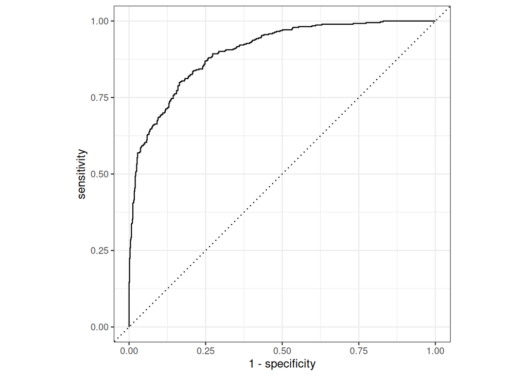

```r
roc_curve_data <- roc_curve(knn_predictions,
                             truth = loan_default,
                             .pred_yes)

# Plot the ROC curve
autoplot(roc_curve_data)
```

```r
roc_auc(knn_predictions, truth = loan_default, .pred_yes)
```

| .metric | .estimator | .estimate |
| --- | --- | --- |
| roc_auc | binary | 0.900929 |

```r
#Confusion Matrix
conf_mat(knn_predictions, truth = loan_default, estimate = .pred_class)
```

```
##           Truth
## Prediction yes  no
##        yes 219  22
##        no  164 623
```

## Model 3: Decision Tree

```r
#Tree Model Specification
tree_model <- decision_tree(cost_complexity = tune(),
                            tree_depth = tune(),
                            min_n = tune()) %>%
  set_engine('rpart') %>%
  set_mode('classification')

#Workflow
tree_workflow <- workflow() %>%
  add_model(tree_model) %>%
  add_recipe(loans_recipe)

#Hyperparameter Tuning -  grid to test
tree_grid <- grid_regular(cost_complexity(),
                          tree_depth(),
                          min_n(),
                          levels = 2)

#Tune decision tree workflow
set.seed(300)

tree_tuning <- tree_workflow %>%
  tune_grid(resamples = loans_folds,
            grid = tree_grid)

#Show top 5 best tree based on ROC AUC
# Show the top models for ROC AUC
best_models <- tree_tuning %>% show_best(metric = "roc_auc", n = 5)

#Select the best model and show it
best_tree <- tree_tuning %>%
  select_best(metric = 'roc_auc')

best_tree
```

| cost_complexity | tree_depth | min_n | .config |
| --- | --- | --- | --- |
| 1e-10 | 15 | 40 | Preprocessor1_Model7 |

```r
#Finalize workflow with best model
final_tree_wf <- tree_workflow %>% finalize_workflow(best_tree)

final_tree_wf
```

```
## ══ Workflow ════════════════════════════════════════════════════════════════════
## Preprocessor: Recipe
## Model: decision_tree()
##
## ── Preprocessor ────────────────────────────────────────────────────────────────
## 3 Recipe Steps
##
## • step_YeoJohnson()
## • step_normalize()
## • step_dummy()
##
## ── Model ───────────────────────────────────────────────────────────────────────
## Decision Tree Model Specification (classification)
##
## Main Arguments:
##   cost_complexity = 1e-10
##   tree_depth = 15
##   min_n = 40
##
## Computational engine: rpart
```

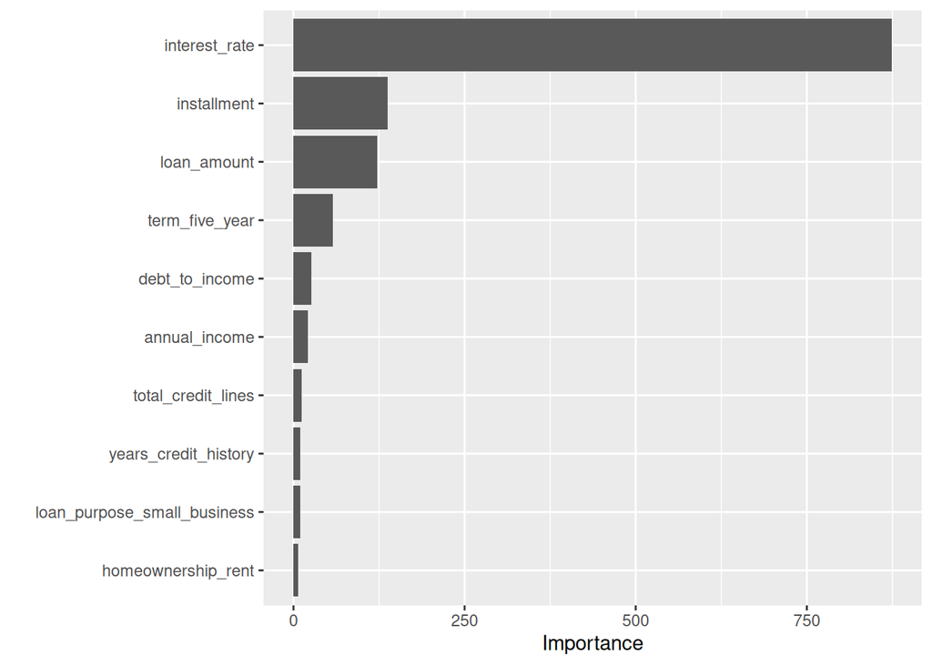

```r
#Fit model
tree_wf_fit <- final_tree_wf %>%
  fit(data = loans_training)

#Trained model
tree_fit <- tree_wf_fit %>%
  pull_workflow_fit()
#Variable Importance
vip(tree_fit)
```

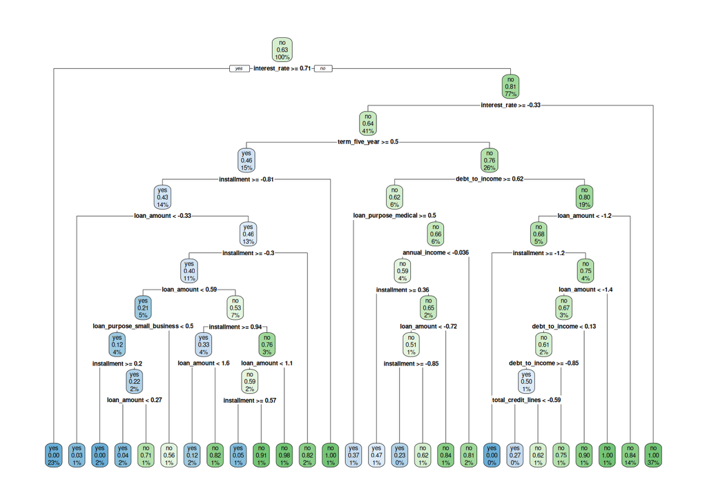

```r
#Decision Tree Plot
rpart.plot(tree_fit$fit, roundint = FALSE)
```

```r
#Train and Evaluate with last_fit()
tree_last_fit <- final_tree_wf %>%
  last_fit(loans_split)

#Accuracy and area under the ROC curve
tree_last_fit %>% collect_metrics()
```

| .metric | .estimator | .estimate | .config |
| --- | --- | --- | --- |
| accuracy | binary | 0.9066148 | Preprocessor1_Model1 |
| roc_auc | binary | 0.9515777 | Preprocessor1_Model1 |
| brier_class | binary | 0.0728629 | Preprocessor1_Model1 |

```r
#Estimated Probabilities
tree_predictions <- tree_last_fit %>%
  collect_predictions()

tree_predictions
```

| .pred_class | .pred_yes | .pred_no | id | .row | loan_default | .config |
| --- | --- | --- | --- | --- | --- | --- |
| yes | 1.00000000 | 0.00000000 | train/test split | 1 | yes | Preprocessor1_Model1 |
| yes | 0.95238095 | 0.04761905 | train/test split | 8 | no | Preprocessor1_Model1 |
| no | 0.00000000 | 1.00000000 | train/test split | 9 | no | Preprocessor1_Model1 |
| yes | 1.00000000 | 0.00000000 | train/test split | 12 | yes | Preprocessor1_Model1 |
| no | 0.00000000 | 1.00000000 | train/test split | 14 | no | Preprocessor1_Model1 |
| no | 0.15837104 | 0.84162896 | train/test split | 15 | yes | Preprocessor1_Model1 |
| no | 0.15837104 | 0.84162896 | train/test split | 20 | no | Preprocessor1_Model1 |
| no | 0.15837104 | 0.84162896 | train/test split | 39 | no | Preprocessor1_Model1 |
| no | 0.15837104 | 0.84162896 | train/test split | 50 | no | Preprocessor1_Model1 |
| yes | 1.00000000 | 0.00000000 | train/test split | 53 | yes | Preprocessor1_Model1 |

[output cut: 1018 more lines]

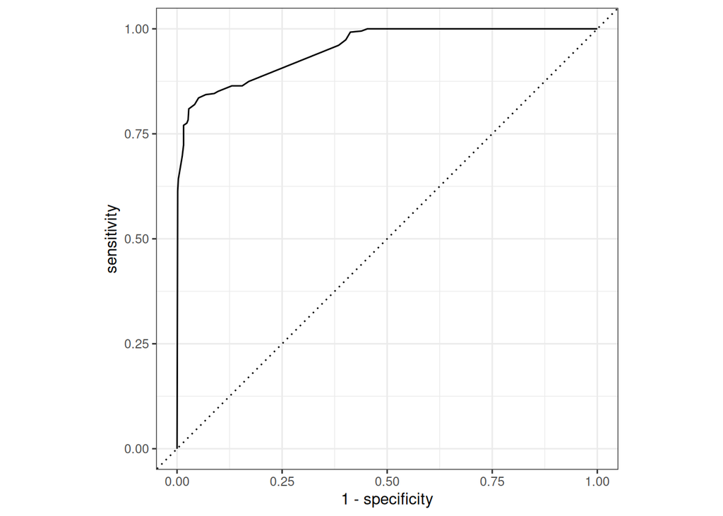

```r
#ROC Curve
# ROC Curve
tree_predictions %>%
  roc_curve(truth = loan_default, .pred_yes) %>%
  autoplot()
```

```r
roc_auc(tree_predictions, truth = loan_default, .pred_yes)
```

| .metric | .estimator | .estimate |
| --- | --- | --- |
| roc_auc | binary | 0.9515777 |

```r
#Confusion Matrix
conf_mat(tree_predictions, truth = loan_default, estimate = .pred_class)
```

```
##           Truth
## Prediction yes  no
##        yes 314  27
##        no   69 618
```

## Summary of Results [50 points]

#1 The most important issue here is determining the factors that influence whether or not a person has defaulted their loan or not. Defaulting a loan means that a person has failed to meet the legal obligations of that loan, such as failing to pay it off. The goal of this analysis was to determine the factors that influenced defaulting a loan and identifying possible ways to encourage someone to not default. Some questions looked at are ones such as “Are there differences in loan default rates by interest rates?”, “Does the term impact the loan default rate?”, and “Does having a history of bankruptcy have an impact on the interest rate between those who default their loans or not?”.

#2 Some interesting findings included the average interest rate of defaulted loans, which loans had the highest average interest rate and highest rate of defaulting, and importance of each factor. These findings give a better insight into which factors could lead to more defaulted loans in the future and to plan ahead in order to try and avoid someone defaulting.

The average interest rate for defaulted loans can be seen in Question 1 of the Data Analysis section. Defaulted loans had an average interest rate of 14.89% where non-defaulted had an average rate of just 9.3%. The difference between the interest rates is 5.59%. The importance of the interest rates here exemplifies that with higher rates, a person is more likely to default their loan because as they miss payments, the higher interest proves to be too much to handle.

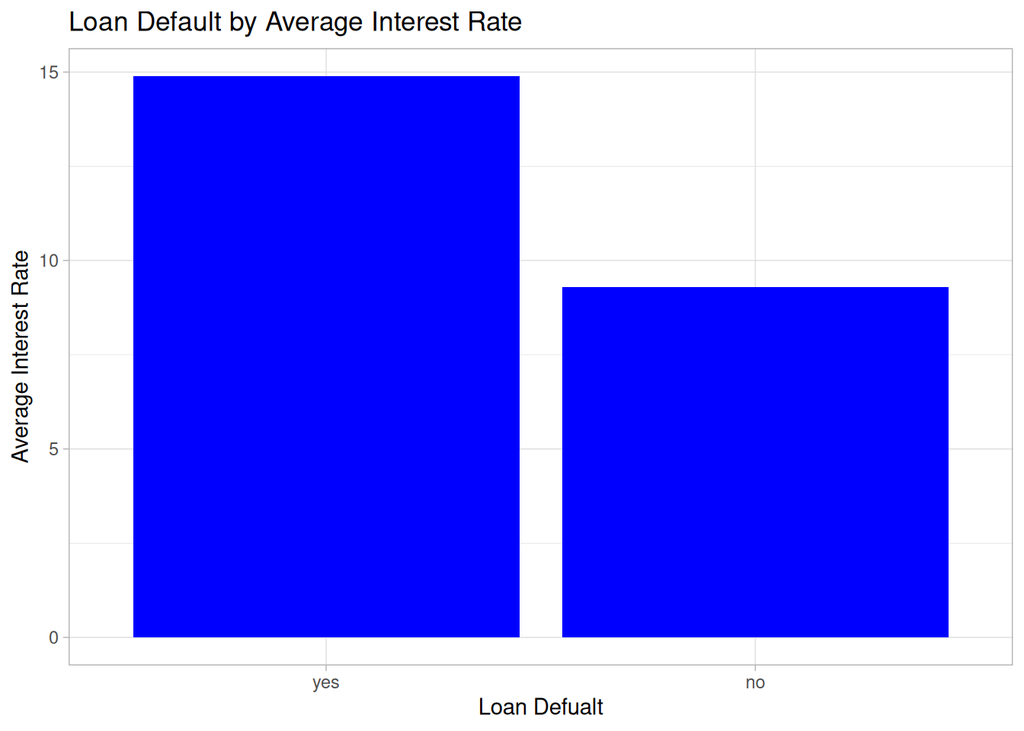

```r
ggplot(data = interest_rates, mapping = aes(x = loan_default, y =avg_int_rate)) +
  geom_bar(stat = 'identity', fill = "blue") +
  labs(title = "Loan Default by Average Interest Rate",
       x = "Loan Defualt",
       y = "Average Interest Rate") +
  theme_light()
```

The next finding were the loans with the highest interest and default rates. These findings can be found in Question 2 of the Data Analysis. What stood out was that the two loans with the highest interest also had the highest rate of defaulted loans, despite the average loan amount for all 5 loans being within $300 of each other. Medical and credit card loans had the highest interest rate and the highest default rates. Both interest rates were over 12% and default rates were 60.47% and 53.47% respectively. Both default rates were at least 25% more than the other loans.

```r
loans_df %>% group_by(loan_purpose) %>%
  summarise(avg_interest = round(mean(interest_rate), 2),
            avg_loan_amount = round(mean(loan_amount), 2),
            default_percent = 100 * round(mean(loan_default == "yes"),4))
```

| loan_purpose | avg_interest | avg_loan_amount | default_percent |
| --- | --- | --- | --- |
| debt_consolidation | 10.62 | 16598.62 | 25.29 |
| credit_card | 12.36 | 16656.23 | 53.47 |
| medical | 12.85 | 16890.98 | 60.47 |
| small_business | 10.70 | 16695.22 | 25.91 |
| home_improvement | 10.86 | 16728.81 | 28.00 |

The final finding to go over is the importance of each factor from the Decision Tree analysis. Here we can see that the interest rate was clearly the most important factor when compared to the others.

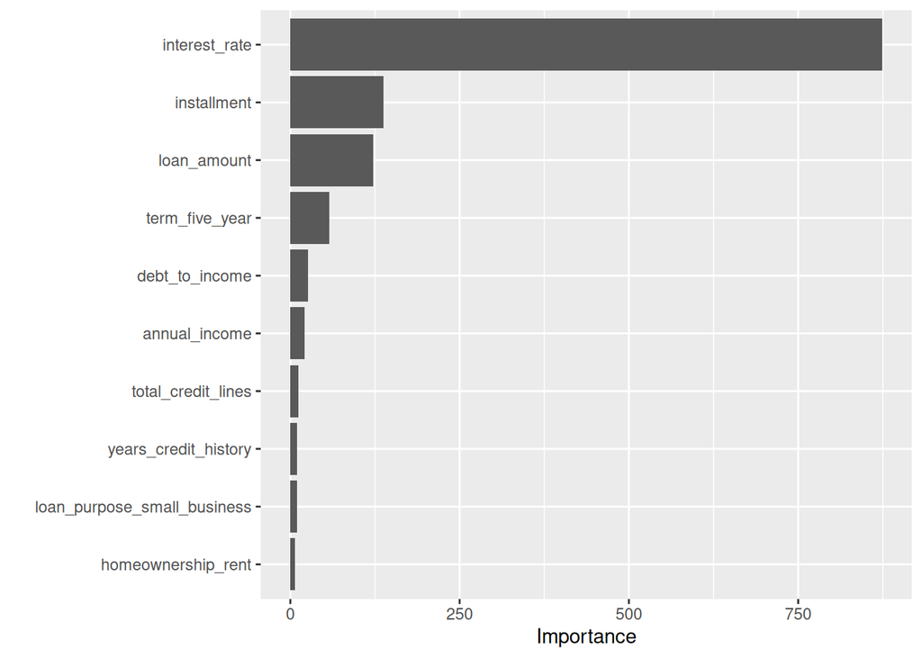

```r
vip(tree_fit)
```

#4 My recommendation to reduce the amount of defaulted loans is to level out the interest rates to make them more even across the board. It was seen in Question 2 that the average loan amount was not an issue as each amount was within a range of $300 from lowest to highest average price. The distinguishing factor there was the average interest rate. Despite the average interest rates for the two most defaulted loans were only 2% higher than the other, the variable importance chart from the Decision Tree analysis backs this statement up. It would appear that the higher the interest rate is, the bigger the chance of someone defaulting that loan. Leveling out the interest rates will retain those who are taking out loans while still making profit off of the interest. Even though this would mean less interest profit, it would be worth it compared to losing a whole loan from being defaulted.

#5 The overall findings of this data analysis and report support the decision that interest rates are the leading factor in a loan being defaulted or not. Between the tibble and the variable importance findings, it was clear to see why that decision was reached based on how much of an influence it had on loans compared to other reasons such as the loan amount and installments. Despite the other factors having some disparities as well, none came close to the level of influence the interest rate had on defaulted loans. All three Predictive Models returned an AUC greater than or equal to 0.9, which shows that the findings were accurate and reliable. Reducing interest rates appears to be the best way to reduce the amount of loans being defaulted based on its level of importance and influence.

— End of the Project —